# Harbour Seal Ontogenetic Diet Family Models

Author

Max Lindmark & Monica Mion

Published

June 2, 2026

## Purpose

This notebook mirrors `03b-diet-models-family.qmd`, but focuses on ontogenetic variation in diet composition.

The workflow is:

- retain colonies through Onsala only,
- retain hunted seals only,
- keep the same dominant prey-family grouping as `03b`,
- build a hunted-seal sample-by-family modelling table,
- test whether seal length changes diet composition,
- then test whether sex adds further structure once length is included.

```r
library(dplyr)
library(tidyr)
library(readr)
library(ggplot2)
library(forcats)
library(stringr)
library(janitor)
library(sf)
library(sdmTMB)
library(purrr)
library(rnaturalearth)
library(ggsidekick)

theme_set(theme_sleek())

home <- here::here()

biomass_file <- file.path(home, "Data", "HS_SKAG_estimated_abundance_biomass_130426.csv")

colony_keep <- c("Koster", "Vaderoarna", "Lysekil", "Marstrand", "Onsala")
analysis_year_min <- 2013L
dominant_families <- c("Gadidae", "Clupeidae", "Pleuronectidae", "Gobiidae")

family_palette <- c(
  "Gadidae"        = "#2E6B1F",
  "Clupeidae"      = "#1F5AA6",
  "Pleuronectidae" = "#D94FD3",
  "Gobiidae"       = "#F39C12",
  "Other"          = "#9E4A7A",
  "Total"          = "#000000"
)

normalize_colony_name <- function(x) {
  x <- trimws(as.character(x))
  case_when(
    grepl("der.*arna", x, ignore.case = TRUE) ~ "Vaderoarna",
    grepl("^Hallands.*der", x, ignore.case = TRUE) ~ "Hallands Vadero",
    TRUE ~ x
  )
}
```

## Read and harmonize source data

```r
sample_meta_workbook <- read_csv(biomass_file, show_col_types = FALSE) |>
  clean_names() |>
  distinct(sample_id, .keep_all = TRUE) |>
  transmute(
    sample_id,
    year_wb = suppressWarnings(as.integer(year)),
    month_wb = suppressWarnings(as.integer(month)),
    quarter_wb = suppressWarnings(as.integer(quarter)),
    latitude_wb = suppressWarnings(as.numeric(latitude)),
    longitude_wb = suppressWarnings(as.numeric(longitude)),
    colony_wb = normalize_colony_name(colony),
    sex_wb = case_when(
      sex %in% c("Female", "Male") ~ as.character(sex),
      TRUE ~ NA_character_
    ),
    age_wb = suppressWarnings(as.numeric(age)),
    body_length_cm_wb = suppressWarnings(as.numeric(body_length_cm)),
    collection_method_wb = if_else(
      is.na(collection_method) | collection_method == "",
      "Unknown",
      as.character(collection_method)
    )
  )

diet_raw <- read_csv(biomass_file, show_col_types = FALSE) |>
  clean_names() |>
  left_join(sample_meta_workbook, by = "sample_id") |>
  mutate(
    year = coalesce(year_wb, suppressWarnings(as.integer(year))),
    month = coalesce(month_wb, suppressWarnings(as.integer(month))),
    quarter = coalesce(quarter_wb, suppressWarnings(as.integer(quarter))),
    latitude = coalesce(latitude_wb, suppressWarnings(as.numeric(latitude))),
    longitude = coalesce(longitude_wb, suppressWarnings(as.numeric(longitude))),
    colony = coalesce(colony_wb, normalize_colony_name(colony)),
    collection_method = coalesce(collection_method_wb, as.character(collection_method)),
    collection_method = if_else(is.na(collection_method) | collection_method == "", "Unknown", collection_method),
    family = if_else(is.na(family) | family == "", "Unknown", family),
    prey_species = prey_species_lat,
    sex = coalesce(sex_wb, case_when(
      sex %in% c("Female", "Male") ~ as.character(sex),
      TRUE ~ NA_character_
    )),
    age = coalesce(age_wb, suppressWarnings(as.numeric(age))),
    body_length_cm = coalesce(body_length_cm_wb, suppressWarnings(as.numeric(body_length_cm))),
    quarter = coalesce(quarter, ((month - 1L) %/% 3L) + 1L)
  ) |>
  select(-ends_with("_wb"))

sample_meta_all <- diet_raw |>
  filter(!is.na(sample_id), !is.na(year), !is.na(latitude), !is.na(longitude)) |>
  distinct(sample_id, .keep_all = TRUE) |>
  transmute(
    sample_id,
    year,
    month,
    quarter,
    lat = latitude,
    lon = longitude,
    collection_method,
    colony,
    sex,
    age,
    body_length_cm
  )

diet_rows_all <- diet_raw |>
  filter(
    !is.na(sample_id),
    !is.na(biomass_not_corrected),
    !is.na(prey_species),
    prey_species != "",
    tolower(prey_species) != "non prey item"
  ) |>
  transmute(
    sample_id,
    family,
    biomass_kg = biomass_not_corrected / 1000
  ) |>
  summarise(biomass_kg = sum(biomass_kg, na.rm = TRUE), .by = c(sample_id, family))

sample_totals_all <- diet_rows_all |>
  summarise(sum_biomass_kg = sum(biomass_kg, na.rm = TRUE), .by = sample_id)

sample_meta_filtered <- sample_meta_all |>
  left_join(sample_totals_all, by = "sample_id") |>
  mutate(sum_biomass_kg = coalesce(sum_biomass_kg, 0)) |>
  filter(
    collection_method == "Hunt",
    colony %in% colony_keep,
    sum_biomass_kg > 0
  )

if (nrow(sample_meta_filtered) == 0) {
  stop("No hunted samples remain after filtering by colony and positive total biomass.")
}

analysis_year_max <- max(sample_meta_filtered$year, na.rm = TRUE)

sample_meta_main <- sample_meta_filtered |>
  filter(year >= analysis_year_min, year <= analysis_year_max)

diet_rows_main <- diet_rows_all |>
  semi_join(sample_meta_main, by = "sample_id")
```

## Support summaries and family grouping

```r
n_main_samples <- nrow(sample_meta_main)

family_levels <- unique(c(dominant_families, "Other"))

family_support_main <- diet_rows_main |>
  summarise(
    total_biomass_kg = sum(biomass_kg, na.rm = TRUE),
    n_samples_present = n_distinct(sample_id[biomass_kg > 0]),
    .by = family
  ) |>
  mutate(
    prevalence = n_samples_present / n_main_samples,
    zero_rate = 1 - prevalence
  ) |>
  arrange(desc(total_biomass_kg))

diet_rows_grouped <- diet_rows_main |>
  mutate(family = if_else(family %in% dominant_families, family, "Other")) |>
  summarise(biomass_kg = sum(biomass_kg, na.rm = TRUE), .by = c(sample_id, family))

family_support_grouped <- diet_rows_grouped |>
  summarise(
    total_biomass_kg = sum(biomass_kg, na.rm = TRUE),
    n_samples_present = n_distinct(sample_id[biomass_kg > 0]),
    .by = family
  ) |>
  mutate(
    prevalence = n_samples_present / n_main_samples,
    zero_rate = 1 - prevalence,
    family = factor(family, levels = family_levels)
  ) |>
  arrange(family)
```

## Build hunted-only model table

```r
year_center <- mean(sample_meta_main$year, na.rm = TRUE)

diet_model_all <- sample_meta_main |>
  select(sample_id, year, month, quarter, lat, lon, colony, sum_biomass_kg, sex, age, body_length_cm) |>
  expand_grid(family = family_levels) |>
  left_join(diet_rows_grouped, by = c("sample_id", "family")) |>
  mutate(
    biomass_kg = coalesce(biomass_kg, 0),
    present = as.integer(biomass_kg > 0),
    prop_biomass = if_else(sum_biomass_kg > 0, biomass_kg / sum_biomass_kg, 0),
    year_ct = year - year_center,
    colony = factor(colony, levels = colony_keep),
    family = factor(family, levels = family_levels),
    sex = factor(sex, levels = c("Female", "Male")),
    year_f = factor(year),
    quarter_f = factor(quarter),
    month_f = factor(month)
  ) |>
  add_utm_columns(ll_names = c("lon", "lat"))

diet_model <- diet_model_all |>
  filter(!is.na(body_length_cm))

diet_model_sex <- diet_model |>
  filter(!is.na(sex))

diet_model |>
  summarise(
    n_samples = n_distinct(sample_id),
    n_rows = n(),
    min_year = min(year),
    max_year = max(year),
    n_families = n_distinct(family),
    length_min = min(body_length_cm),
    length_max = max(body_length_cm)
  )
```

```
# A tibble: 1 x 7
  n_samples n_rows min_year max_year n_families length_min length_max
      <int>  <int>    <int>    <int>      <int>      <dbl>      <dbl>
1       388   1940     2013     2025          5         80        203
```

## Support diagnostics

```r
hunt_samples_by_year <- sample_meta_main |>
  count(year, name = "n_samples")

missing_covariates <- sample_meta_main |>
  summarise(
    n_samples = n(),
    n_length = sum(!is.na(body_length_cm)),
    n_sex = sum(!is.na(sex)),
    n_age = sum(!is.na(age)),
    n_length_sex = sum(!is.na(body_length_cm) & !is.na(sex)),
    n_all_three = sum(!is.na(body_length_cm) & !is.na(sex) & !is.na(age))
  )

age_length_plot <- sample_meta_main |>
  filter(!is.na(body_length_cm), !is.na(age), !is.na(sex)) |>
  ggplot(aes(age, body_length_cm, color = sex)) +
  geom_point(alpha = 0.6) +
  geom_smooth(method = "lm", se = FALSE, linewidth = 1) +
  labs(
    title = "Relation between seal age and length",
    subtitle = "Separate fitted lines for female and male hunted seals",
    x = "Age",
    y = "Body length (cm)",
    color = "Sex"
  )

length_histogram <- sample_meta_main |>
  filter(!is.na(body_length_cm)) |>
  ggplot(aes(body_length_cm)) +
  geom_histogram(binwidth = 5, color = "white", fill = "grey40") +
  labs(
    title = "Seal length distribution in hunted samples",
    x = "Body length (cm)",
    y = "Samples"
  )

length_histogram_sex_colony <- sample_meta_main |>
  filter(!is.na(body_length_cm), !is.na(sex)) |>
  mutate(colony = factor(colony, levels = colony_keep)) |>
  ggplot(aes(body_length_cm, fill = sex)) +
  geom_histogram(binwidth = 5, color = "white") +
  facet_wrap(~colony, ncol = 1, scales = "free_y") +
  labs(
    title = "Seal length distribution in hunted samples by colony and sex",
    subtitle = "Colonies ordered from north to south",
    x = "Body length (cm)",
    y = "Samples",
    fill = "Sex"
  )

length_by_year <- sample_meta_main |>
  filter(!is.na(body_length_cm)) |>
  ggplot(aes(year, body_length_cm)) +
  geom_point(alpha = 0.5) +
  geom_smooth(method = "lm", se = TRUE, color = "black") +
  labs(
    title = "Seal length over time",
    x = "Year",
    y = "Body length (cm)"
  )

sex_balance <- sample_meta_main |>
  filter(!is.na(sex)) |>
  count(sex) |>
  ggplot(aes(sex, n, fill = sex)) +
  geom_col(show.legend = FALSE) +
  labs(
    title = "Sex balance in hunted samples",
    x = NULL,
    y = "Samples"
  )

sex_balance_colony <- sample_meta_main |>
  filter(!is.na(sex)) |>
  mutate(colony = factor(colony, levels = colony_keep)) |>
  count(colony, sex, name = "n") |>
  group_by(colony) |>
  mutate(
    total_n = sum(n),
    prop = n / total_n
  ) |>
  ungroup() |>
  ggplot(aes(colony, prop, fill = sex)) +
  geom_col() +
  geom_text(
    data = ~ distinct(.x, colony, total_n),
    aes(x = colony, y = 1.02, label = total_n),
    inherit.aes = FALSE,
    vjust = 0
  ) +
  scale_y_continuous(
    labels = scales::percent_format(accuracy = 1),
    limits = c(0, 1.08),
    expand = c(0, 0)
  ) +
  labs(
    title = "Relative sex composition by colony",
    subtitle = "Numbers above bars show total hunted samples with known sex",
    x = NULL,
    y = "Relative abundance",
    fill = "Sex"
  )

family_support_plot <- family_support_grouped |>
  mutate(family = fct_reorder(as.character(family), total_biomass_kg)) |>
  ggplot(aes(total_biomass_kg, family)) +
  geom_col(fill = "steelblue") +
  labs(
    title = "Grouped prey families retained for modelling",
    subtitle = "Same dominant-family set as 03b",
    x = "Total biomass (kg)",
    y = NULL
  )

missing_covariates
```

```
# A tibble: 1 x 6
  n_samples n_length n_sex n_age n_length_sex n_all_three
      <int>    <int> <int> <int>        <int>       <int>
1       401      388   381   142          376         134
```

```r
hunt_samples_by_year
```

```
# A tibble: 13 x 2
    year n_samples
   <int>     <int>
 1  2013        43
 2  2014        77
 3  2015        55
 4  2016        44
 5  2017         2
 6  2018         3
 7  2019        15
 8  2020        46
 9  2021        28
10  2022         6
11  2023        37
12  2024        30
13  2025        15
```

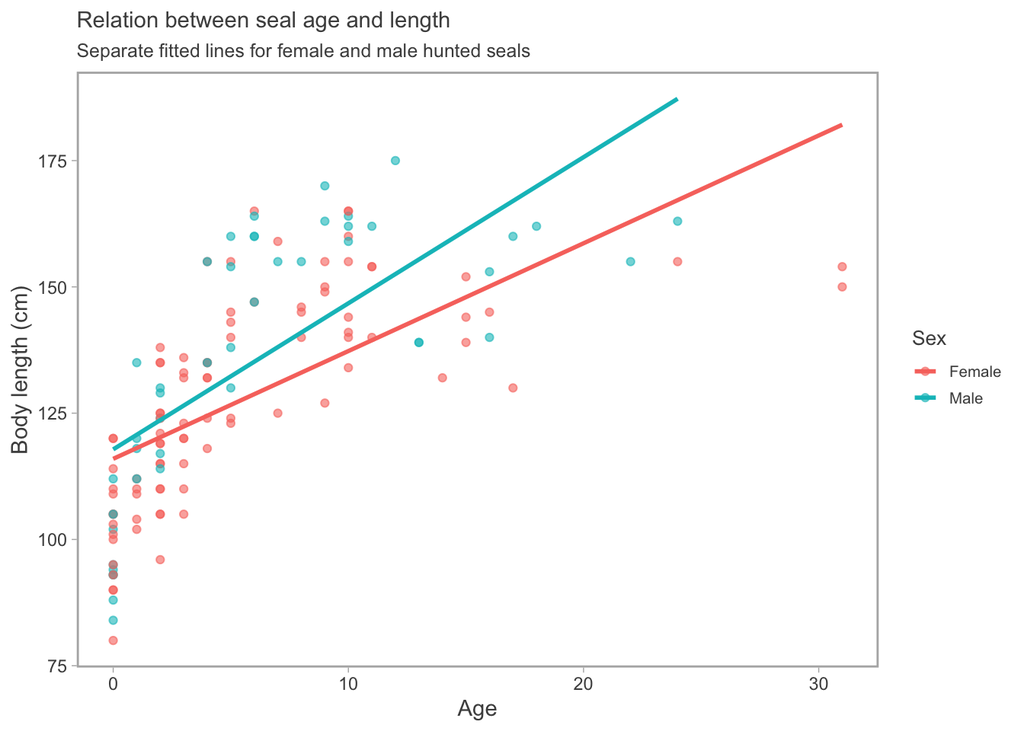

```r
age_length_plot
```

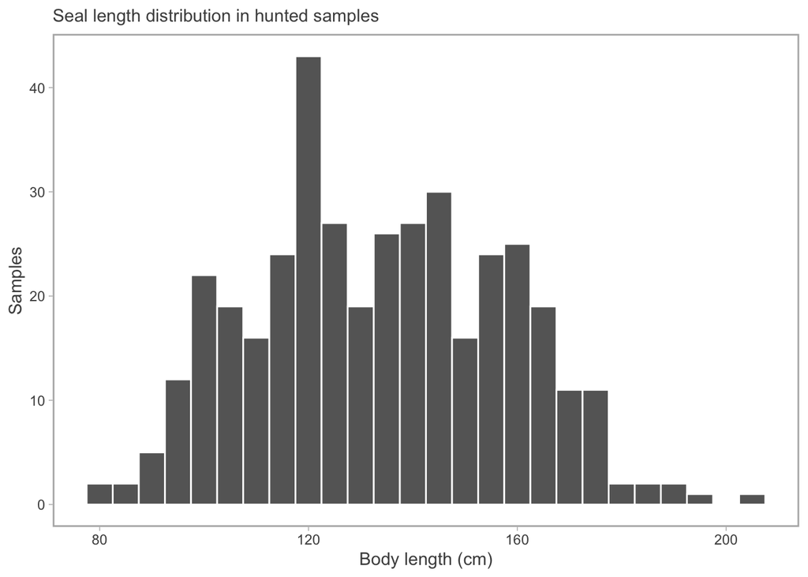

```r
length_histogram
```

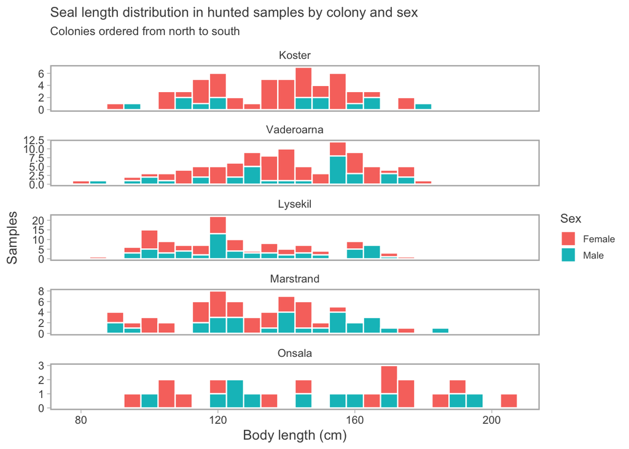

```r
length_histogram_sex_colony
```

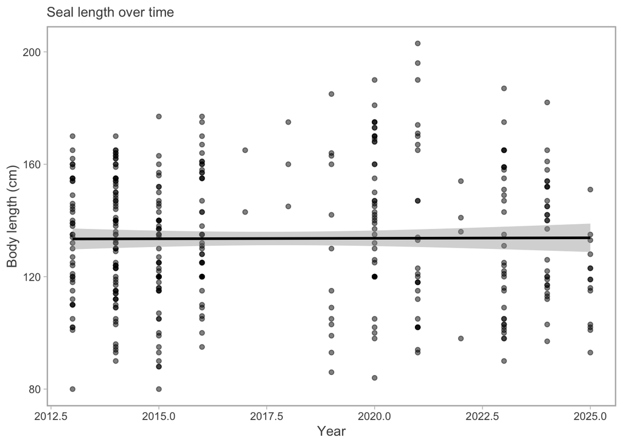

```r
length_by_year
```

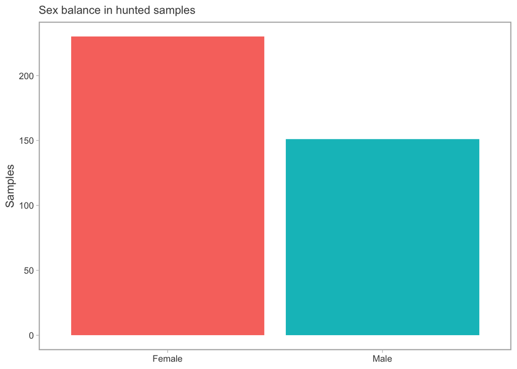

```r
sex_balance
```

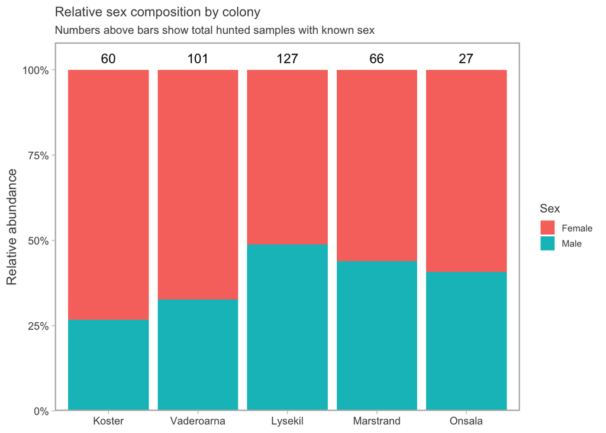

```r
sex_balance_colony
```

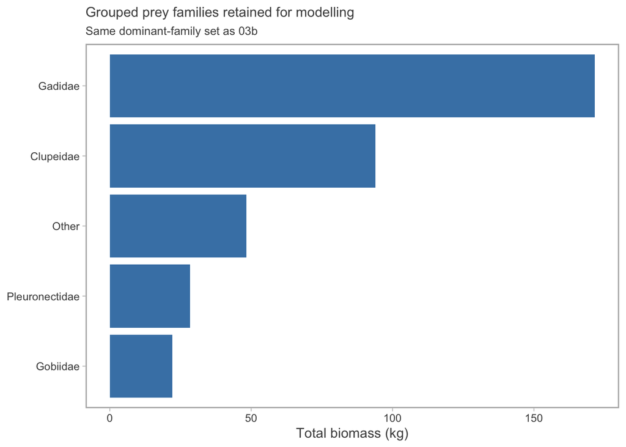

```r
family_support_plot
```

## Prediction grid

```r
d <- diet_model

hull_idx <- chull(d$X, d$Y)
hull_coords <- cbind(d$X[hull_idx], d$Y[hull_idx])
hull_coords <- rbind(hull_coords, hull_coords[1, ])

sp_poly <- sp::SpatialPolygons(
  list(sp::Polygons(list(sp::Polygon(hull_coords)), ID = 1))
)

sp_poly_df <- sp::SpatialPolygonsDataFrame(
  sp_poly,
  data = data.frame(ID = 1)
)

cell_width <- 0.5

pred_grid_base <- expand.grid(
  X = seq(min(d$X), max(d$X), cell_width),
  Y = seq(min(d$Y), max(d$Y), cell_width),
  year = seq(min(d$year), max(d$year))
)

sp::coordinates(pred_grid_base) <- c("X", "Y")

inside <- !is.na(sp::over(pred_grid_base, as(sp_poly_df, "SpatialPolygons")))

pred_grid_base <- pred_grid_base[inside, ]

pred_grid_base <- as.data.frame(pred_grid_base) |>
  mutate(
    year_ct = year - year_center,
    year_f = factor(year, levels = levels(diet_model$year_f))
  )

land <- ne_countries(scale = "large", returnclass = "sf") |>
  st_transform(32632)
```

## Mesh

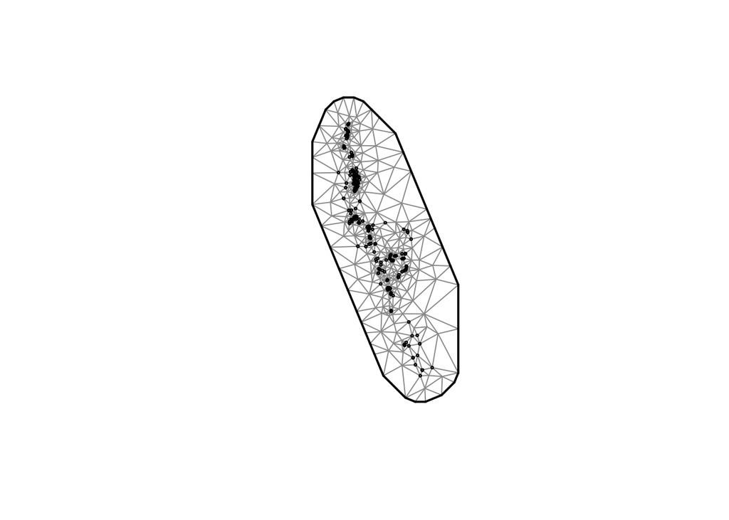

```r
mesh_cutoff_km <- 0.5

mesh <- make_mesh(diet_model, xy_cols = c("X", "Y"), type = "cutoff", cutoff = mesh_cutoff_km)

plot(mesh)
```

## Shared prediction reference

```r
prediction_reference <- sample_meta_main |>
  filter(!is.na(body_length_cm), !is.na(sex)) |>
  summarise(
    pred_year = round(median(sort(unique(year)))),
    pred_length_cm = median(body_length_cm, na.rm = TRUE)
  )

pred_year_common <- prediction_reference$pred_year
pred_length_common <- prediction_reference$pred_length_cm
```

## Family-level Gadidae questions: sex, length, year, space

This section keeps the earlier family-level workflow. It fits one joint family model on all retained family groups, converts predictions to diet composition, and then filters the prediction output to `Gadidae`.

```r
diet_model_gad <- diet_model_sex |>
  mutate(body_length_ct = body_length_cm - mean(body_length_cm, na.rm = TRUE))

mesh_gad <- make_mesh(diet_model_gad, xy_cols = c("X", "Y"), type = "cutoff", cutoff = mesh_cutoff_km)

# Do females and males differ in diet choice? After accounting for length
g1 <- sdmTMB(
  formula = biomass_kg ~ sex*family + body_length_cm + (1|year_f),
  data = diet_model_gad,
  mesh = mesh_gad,
  family = tweedie(),
  spatial = "on"
)

# Length-specific diet
g2 <- sdmTMB(
  formula = biomass_kg ~ sex*family + body_length_cm*family + (1|year_f),
  data = diet_model_gad,
  mesh = mesh_gad,
  family = tweedie(),
  spatial = "on"
)

# Length-specific diet (nonlinear ontogenetic diet change)
g3 <- sdmTMB(
  formula = biomass_kg ~ sex*family + s(body_length_cm, by = family) + (1|year_f),
  data = diet_model_gad,
  mesh = mesh_gad,
  family = tweedie(),
  spatial = "on"
)

# Different length effects by sex
g4 <- sdmTMB(
  formula = biomass_kg ~ sex*family + body_length_cm*sex + (1|year_f),
  data = diet_model_gad,
  mesh = mesh_gad,
  family = tweedie(),
  spatial = "on"
)

# Spatial fields by family
g5 <- sdmTMB(
  formula = biomass_kg ~ sex*family + body_length_cm + (1|year_f),
  data = diet_model_gad,
  mesh = mesh_gad,
  family = tweedie(),
  spatial = "off",
  spatial_varying = ~ 0 + family
)

# Spatial fields by family with body length by family
g6 <- sdmTMB(
  formula = biomass_kg ~ sex*family + body_length_cm*family + (1|year_f),
  data = diet_model_gad,
  mesh = mesh_gad,
  family = tweedie(),
  spatial = "off",
  spatial_varying = ~ 0 + family
)

# Three-way interaction
g7 <- sdmTMB(
  formula = biomass_kg ~ body_length_cm*family*sex + (1|year_f),
  data = diet_model_gad,
  mesh = mesh_gad,
  family = tweedie(),
  spatial = "off",
  spatial_varying = ~ 0 + family
)

# g6 but with spatiotemporal fields
g8 <- sdmTMB(
  formula = biomass_kg ~ sex*family + body_length_cm*family + (1|year_f),
  data = diet_model_gad,
  mesh = mesh_gad,
  family = tweedie(),
  spatial = "off",
  spatiotemporal = "iid",
  time = "year",
  spatial_varying = ~ 0 + family
)

# Does the effect of sex differ between quarters?
g9 <- sdmTMB(
  formula = biomass_kg ~ sex*family + quarter_f*sex + body_length_cm*family + (1|year_f),
  data = diet_model_gad,
  mesh = mesh_gad,
  family = tweedie(),
  spatial = "off",
  spatial_varying = ~ 0 + family
)

# Simple seasonal effect
g10 <- sdmTMB(
  formula = biomass_kg ~ sex*family + quarter_f + body_length_cm*family + (1|year_f),
  data = diet_model_gad,
  mesh = mesh_gad,
  family = tweedie(),
  spatial = "off",
  spatial_varying = ~ 0 + family
)

AIC(g1, g2, g3, g4, g5, g6, g7, g8, g9, g10) |>
  arrange(AIC)
```

```
    df      AIC
g6  24 1651.291
g8  25 1653.291
g10 27 1654.558
g5  20 1657.125
g9  30 1658.760
g7  29 1659.371
g2  20 1852.151
g3  25 1856.384
g1  16 1871.488
g4  17 1873.325
```

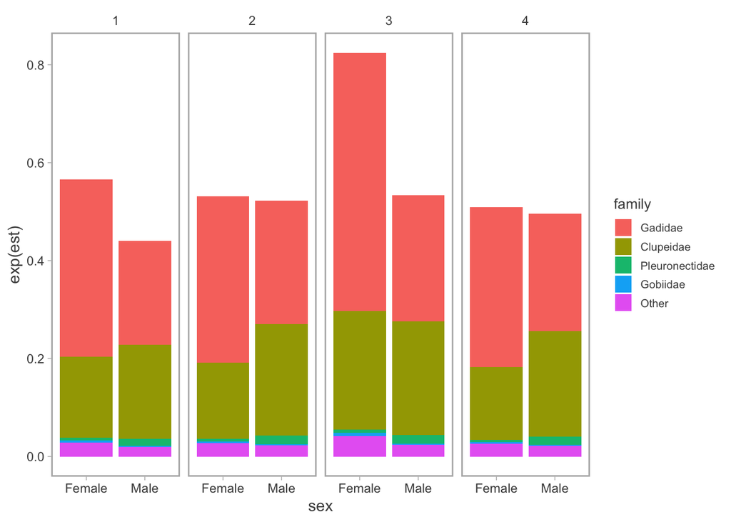

```r
# Season effects from the family-level model using the shared reference seal.
nd <- expand_grid(
  quarter_f = as.factor(c(1:4)),
  family = unique(diet_model_gad$family),
  sex = unique(diet_model_gad$sex)
) |>
  mutate(
    body_length_cm = pred_length_common,
    year = pred_year_common,
    year_ct = year - year_center,
    year_f = factor(year, levels = levels(diet_model_gad$year_f)),
    X = median(diet_model_gad$X, na.rm = TRUE),
    Y = median(diet_model_gad$Y, na.rm = TRUE)
  )

p <- predict(g9, newdata = nd, re_form = NA, re_form_iid = NA)

ggplot(p, aes(sex, exp(est), fill = family)) +
  facet_wrap(~quarter_f, ncol = 4) +
  geom_bar(stat = "identity")
```

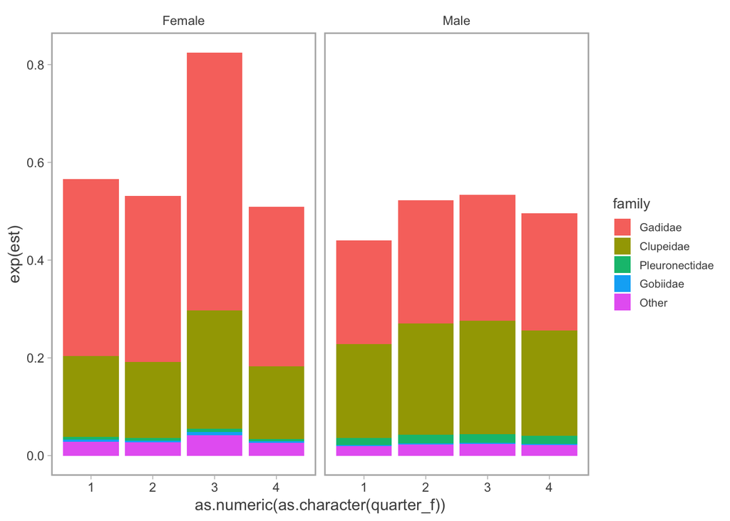

```r
ggplot(p, aes(as.numeric(as.character(quarter_f)), exp(est), fill = family)) +
  facet_wrap(~sex, ncol = 4) +
  geom_bar(stat = "identity")
```

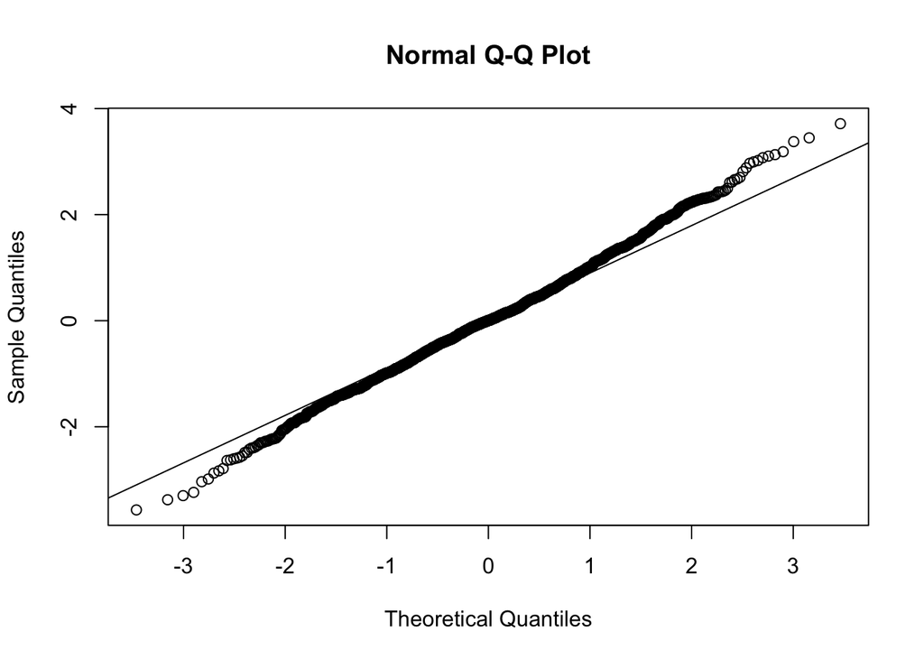

```r
qqnorm(residuals(g9)); qqline(residuals(g9))
```

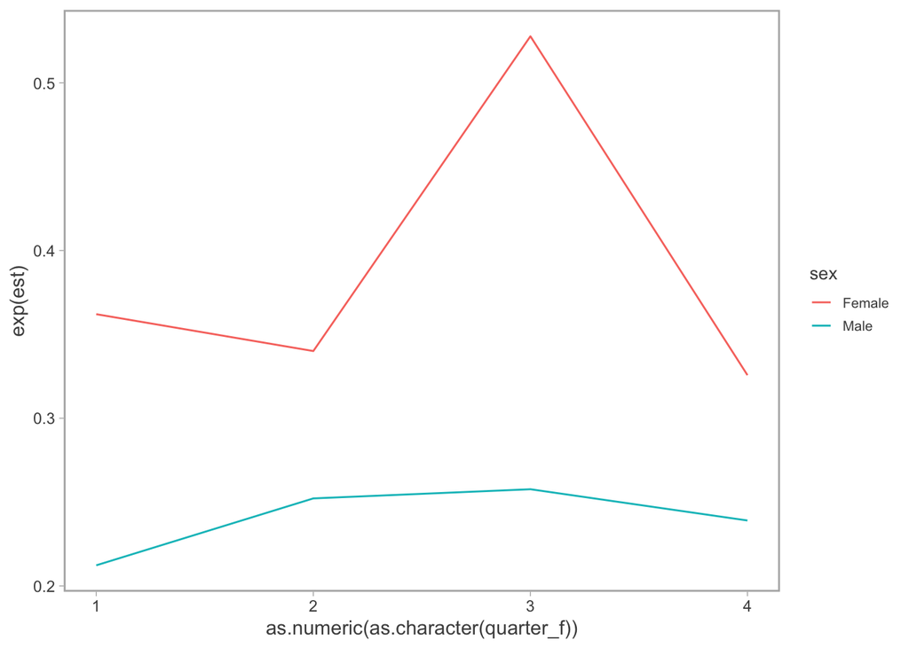

```r
# Quarter effect for Gadidae by sex at the same reference seal and year.
nd <- expand_grid(
  quarter_f = factor(c(1:4), levels = levels(diet_model_gad$quarter_f)),
  sex = unique(diet_model_gad$sex)
) |>
  mutate(
    body_length_cm = pred_length_common,
    family = "Gadidae",
    year = pred_year_common,
    year_ct = year - year_center,
    year_f = factor(year, levels = levels(diet_model_gad$year_f)),
    X = median(diet_model_gad$X, na.rm = TRUE),
    Y = median(diet_model_gad$Y, na.rm = TRUE)
  )

p <- predict(g9, newdata = nd, re_form = NA, re_form_iid = NA)

ggplot(p, aes(as.numeric(as.character(quarter_f)), exp(est), color = sex)) +
  geom_line()
```

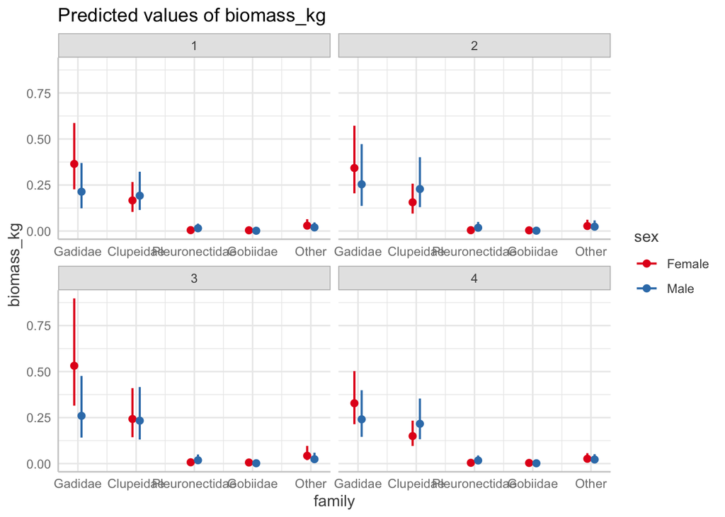

```r
plot(ggeffects::ggpredict(g9, c("family", "sex", "quarter_f")))
```

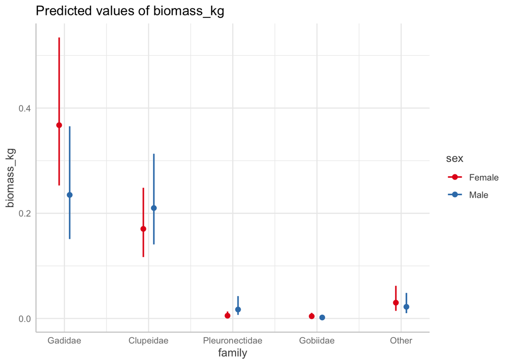

```r
plot(ggeffects::ggpredict(g6, c("family", "sex")))
```

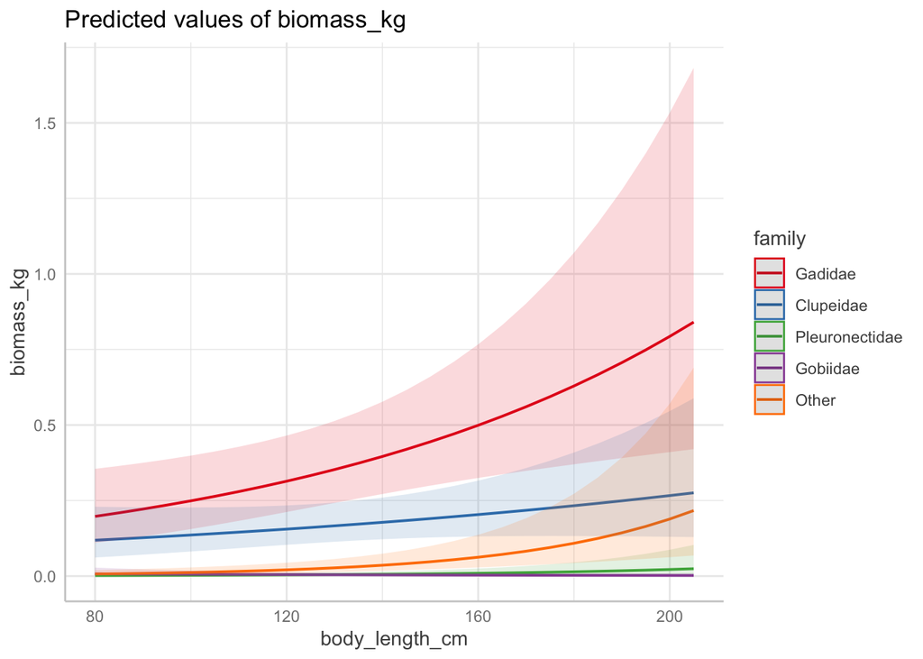

```r
plot(ggeffects::ggpredict(g6, c("body_length_cm", "family")))
```

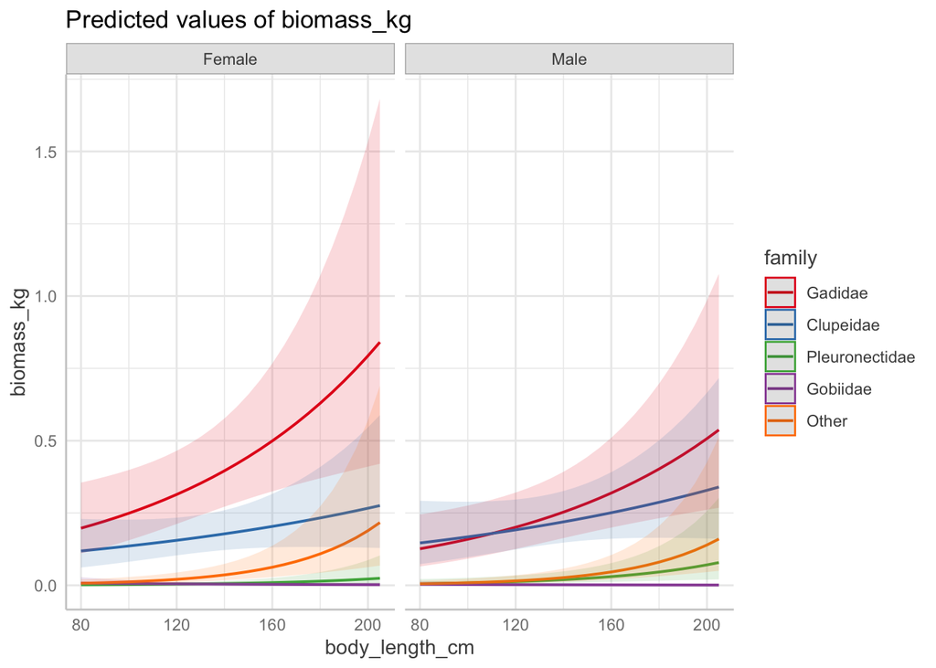

```r
plot(ggeffects::ggpredict(g6, c("body_length_cm", "family", "sex")))
```

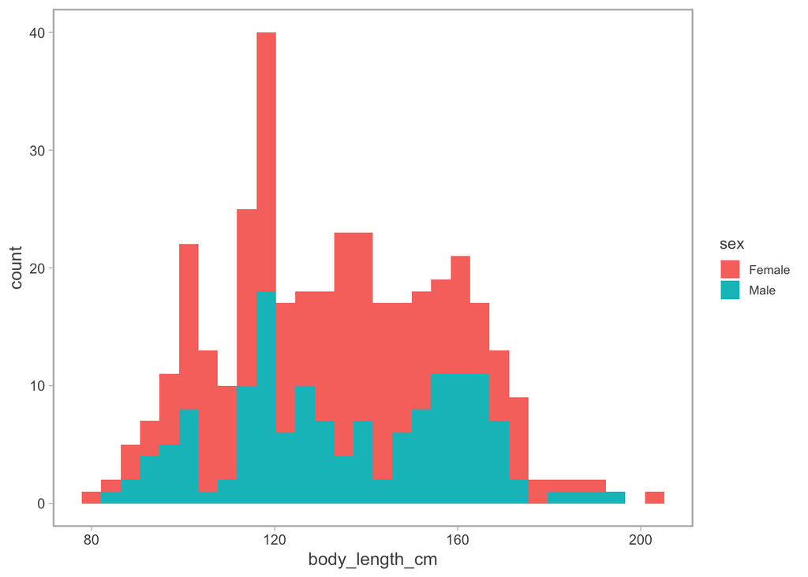

```r
diet_model_gad |>
  distinct(sample_id, body_length_cm, sex) |>
  ggplot(aes(body_length_cm, fill = sex)) +
  geom_histogram()
```

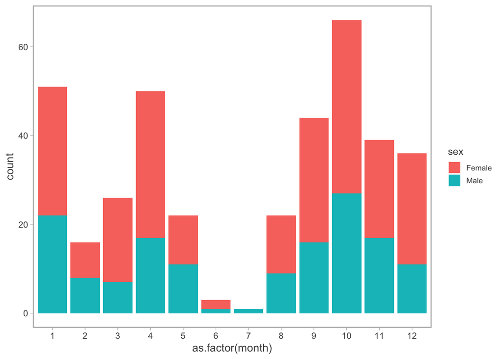

```r
diet_model_gad |>
  distinct(sample_id, month, sex) |>
  ggplot(aes(as.factor(month), fill = sex)) +
  geom_bar()
```

## Hybrid prey-group questions: sex, length, year, space

This section uses one hybrid prey grouping for the hunted samples:

- split `Gadidae` into the most supported scientific-name labels,
- keep the remaining gadids as `Other Gadidae`,
- keep non-gadid prey at the same grouped family level used above.

```r
gad_species_keep <- c(
  "Gadus morhua",
  "Merlangius merlangus",
  "Pollachius sp. / Melanogrammus aeglefinus",
  "Gadidae"
)

prey_group_levels <- c(
  gad_species_keep,
  "Other Gadidae",
  "Clupeidae",
  "Pleuronectidae",
  "Gobiidae",
  "Other"
)

hybrid_rows <- diet_raw |>
  filter(
    !is.na(sample_id),
    !is.na(biomass_not_corrected),
    !is.na(prey_species),
    prey_species != "",
    tolower(prey_species) != "non prey item"
  ) |>
  transmute(
    sample_id,
    prey_group = case_when(
      family == "Gadidae" & prey_species %in% gad_species_keep ~ prey_species,
      family == "Gadidae" ~ "Other Gadidae",
      family == "Clupeidae" ~ "Clupeidae",
      family == "Pleuronectidae" ~ "Pleuronectidae",
      family == "Gobiidae" ~ "Gobiidae",
      TRUE ~ "Other"
    ),
    biomass_kg = biomass_not_corrected / 1000
  ) |>
  summarise(biomass_kg = sum(biomass_kg, na.rm = TRUE), .by = c(sample_id, prey_group))

prey_group_support <- hybrid_rows |>
  semi_join(sample_meta_main |> filter(!is.na(body_length_cm), !is.na(sex)), by = "sample_id") |>
  summarise(
    total_biomass_kg = sum(biomass_kg, na.rm = TRUE),
    n_samples_present = n_distinct(sample_id[biomass_kg > 0]),
    .by = prey_group
  ) |>
  mutate(prey_group = factor(prey_group, levels = prey_group_levels)) |>
  arrange(prey_group)

diet_model_hybrid <- sample_meta_main |>
  filter(!is.na(body_length_cm), !is.na(sex)) |>
  select(sample_id, year, month, quarter, lat, lon, colony, sum_biomass_kg, sex, body_length_cm) |>
  expand_grid(prey_group = prey_group_levels) |>
  left_join(hybrid_rows, by = c("sample_id", "prey_group")) |>
  mutate(
    biomass_kg = coalesce(biomass_kg, 0),
    year_ct = year - year_center,
    year_f = factor(year),
    quarter_f = factor(quarter),
    prey_group = factor(prey_group, levels = prey_group_levels),
    sex = factor(sex, levels = c("Female", "Male"))
  ) |>
  add_utm_columns(ll_names = c("lon", "lat"))

prey_group_support
```

```
# A tibble: 9 x 3
  prey_group                                total_biomass_kg n_samples_present
  <fct>                                                <dbl>             <int>
1 Gadus morhua                                          57.1               125
2 Merlangius merlangus                                  37.2               120
3 Pollachius sp. / Melanogrammus aeglefinus             32.0                89
4 Gadidae                                               24.5               142
5 Other Gadidae                                         13.7                92
6 Clupeidae                                             86.1               241
7 Pleuronectidae                                        22.6                72
8 Gobiidae                                              22.0               115
9 Other                                                 46.5               145
```

```r
mesh_hybrid <- make_mesh(diet_model_hybrid, xy_cols = c("X", "Y"), type = "cutoff", cutoff = mesh_cutoff_km)

h1 <- sdmTMB(
  formula = biomass_kg ~ sex * prey_group + body_length_cm + (1 | year_f),
  data = diet_model_hybrid,
  mesh = mesh_hybrid,
  family = tweedie(),
  spatial = "on"
)

h2 <- sdmTMB(
  formula = biomass_kg ~ sex * prey_group + body_length_cm * prey_group + (1 | year_f),
  data = diet_model_hybrid,
  mesh = mesh_hybrid,
  family = tweedie(),
  spatial = "on"
)

h3 <- sdmTMB(
  formula = biomass_kg ~ sex * prey_group + s(body_length_cm, by = prey_group) + (1 | year_f),
  data = diet_model_hybrid,
  mesh = mesh_hybrid,
  family = tweedie(),
  spatial = "on"
)

h4 <- sdmTMB(
  formula = biomass_kg ~ sex * prey_group + body_length_cm * sex + (1 | year_f),
  data = diet_model_hybrid,
  mesh = mesh_hybrid,
  family = tweedie(),
  spatial = "on"
)

h5 <- sdmTMB(
  formula = biomass_kg ~ sex * prey_group + body_length_cm + (1 | year_f),
  data = diet_model_hybrid,
  mesh = mesh_hybrid,
  family = tweedie(),
  spatial = "off",
  spatial_varying = ~ 0 + prey_group
)

h6 <- sdmTMB(
  formula = biomass_kg ~ sex * prey_group + body_length_cm * prey_group + (1 | year_f),
  data = diet_model_hybrid,
  mesh = mesh_hybrid,
  family = tweedie(),
  spatial = "off",
  spatial_varying = ~ 0 + prey_group
)

h7 <- sdmTMB(
  formula = biomass_kg ~ body_length_cm * prey_group * sex + (1 | year_f),
  data = diet_model_hybrid,
  mesh = mesh_hybrid,
  family = tweedie(),
  spatial = "off",
  spatial_varying = ~ 0 + prey_group
)

h8 <- sdmTMB(
  formula = biomass_kg ~ sex * prey_group + body_length_cm * prey_group + (1 | year_f),
  data = diet_model_hybrid,
  mesh = mesh_hybrid,
  family = tweedie(),
  spatial = "off",
  spatiotemporal = "iid",
  time = "year",
  spatial_varying = ~ 0 + prey_group
)

h9 <- sdmTMB(
  formula = biomass_kg ~ sex * prey_group + quarter_f * sex + body_length_cm * prey_group + (1 | year_f),
  data = diet_model_hybrid,
  mesh = mesh_hybrid,
  family = tweedie(),
  spatial = "off",
  spatial_varying = ~ 0 + prey_group
)

h10 <- sdmTMB(
  formula = biomass_kg ~ sex * prey_group + quarter_f + body_length_cm * prey_group + (1 | year_f),
  data = diet_model_hybrid,
  mesh = mesh_hybrid,
  family = tweedie(),
  spatial = "off",
  spatial_varying = ~ 0 + prey_group
)

AIC(h1, h2, h3, h4, h5, h6, h7, h8, h9, h10) |>
  arrange(AIC)
```

```
    df      AIC
h8  41 2781.036
h6  40 2783.321
h10 43 2784.115
h5  32 2785.924
h9  46 2789.311
h7  49 2794.860
h2  32 2987.674
h3  41 2988.129
h1  24 3003.203
h4  25 3005.160
```

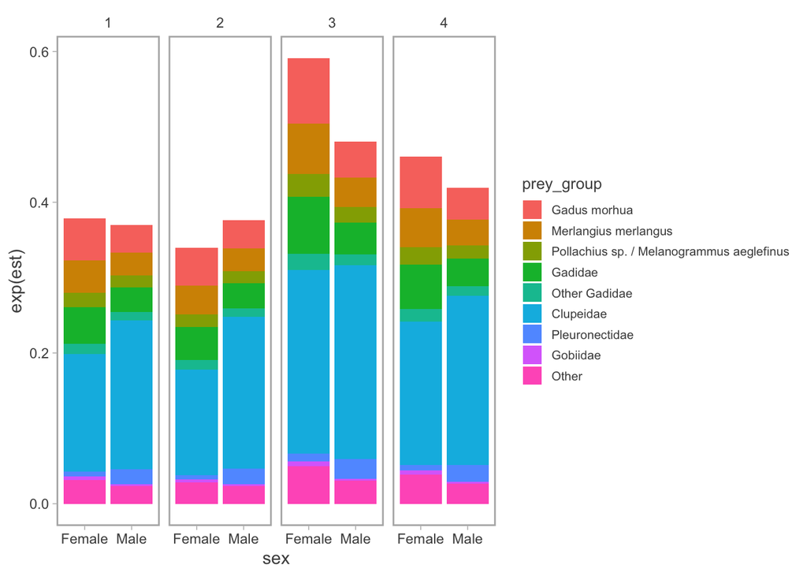

```r
pred_year_hybrid <- pred_year_common
pred_length_hybrid <- pred_length_common

# Season effects from the hybrid model using the same reference seal and year as the family plots.
nd_hybrid <- expand_grid(
  quarter_f = factor(c(1:4), levels = levels(diet_model_hybrid$quarter_f)),
  prey_group = factor(prey_group_levels, levels = prey_group_levels),
  sex = unique(diet_model_hybrid$sex)
) |>
  mutate(
    body_length_cm = pred_length_hybrid,
    year = pred_year_hybrid,
    year_ct = year - year_center,
    year_f = factor(year, levels = levels(diet_model_hybrid$year_f)),
    X = median(diet_model_hybrid$X, na.rm = TRUE),
    Y = median(diet_model_hybrid$Y, na.rm = TRUE)
  )

p_hybrid <- predict(h9, newdata = nd_hybrid, re_form = NA, re_form_iid = NA)

ggplot(p_hybrid, aes(sex, exp(est), fill = prey_group)) +
  facet_wrap(~quarter_f, ncol = 4) +
  geom_bar(stat = "identity")
```

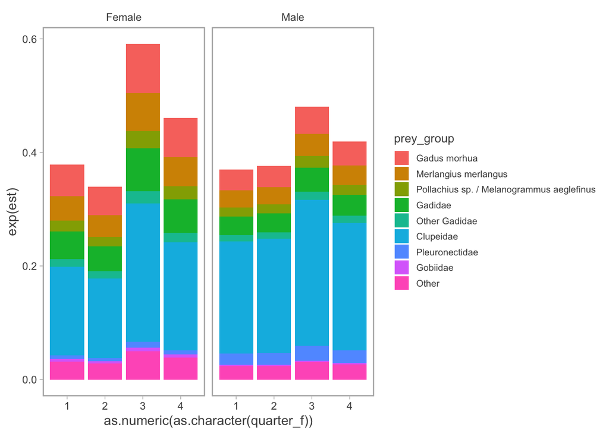

```r
ggplot(p_hybrid, aes(as.numeric(as.character(quarter_f)), exp(est), fill = prey_group)) +
  facet_wrap(~sex, ncol = 4) +
  geom_bar(stat = "identity")
```

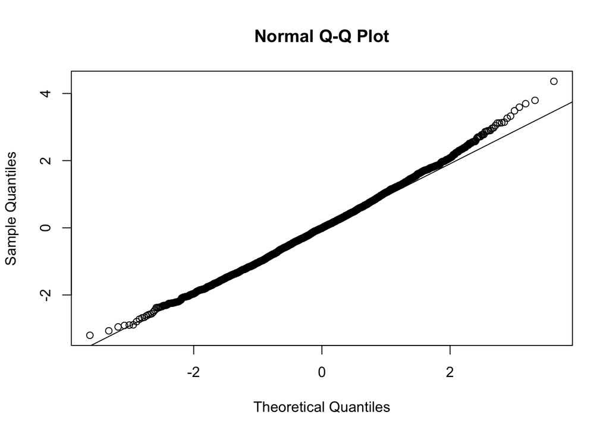

```r
qqnorm(residuals(h9)); qqline(residuals(h9))
```

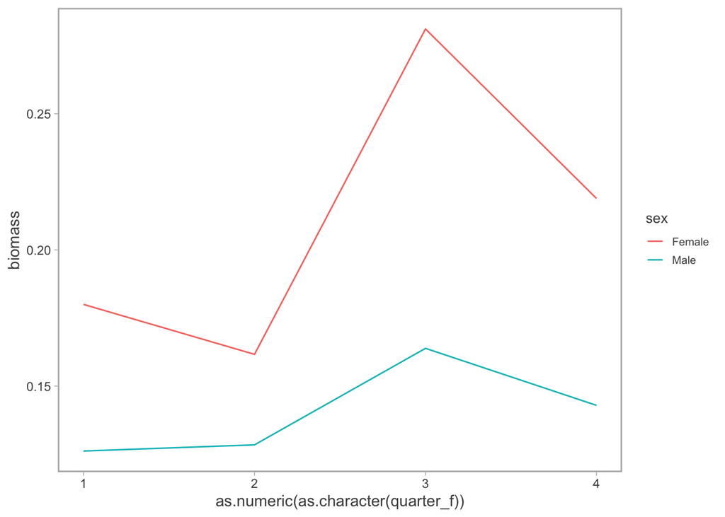

```r
# Quarter effect for aggregated gadid prey by sex at the same reference seal and year.
nd_hybrid_gad <- expand_grid(
  quarter_f = factor(c(1:4), levels = levels(diet_model_hybrid$quarter_f)),
  sex = unique(diet_model_hybrid$sex),
  prey_group = factor(c(gad_species_keep, "Other Gadidae"), levels = prey_group_levels)
) |>
  mutate(
    body_length_cm = pred_length_hybrid,
    year = pred_year_hybrid,
    year_ct = year - year_center,
    year_f = factor(year, levels = levels(diet_model_hybrid$year_f)),
    X = median(diet_model_hybrid$X, na.rm = TRUE),
    Y = median(diet_model_hybrid$Y, na.rm = TRUE)
  )

p_hybrid_gad <- predict(h9, newdata = nd_hybrid_gad, re_form = NA, re_form_iid = NA)

hybrid_gad_quarter <- nd_hybrid_gad |>
  bind_cols(as_tibble(p_hybrid_gad) |> select(est)) |>
  mutate(biomass = exp(est)) |>
  summarise(biomass = sum(biomass), .by = c(quarter_f, sex))

ggplot(hybrid_gad_quarter, aes(as.numeric(as.character(quarter_f)), biomass, color = sex)) +
  geom_line()
```

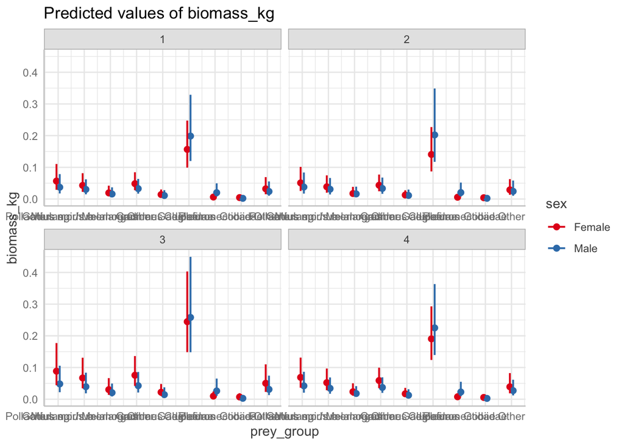

```r
plot(ggeffects::ggpredict(h9, c("prey_group", "sex", "quarter_f")))
```

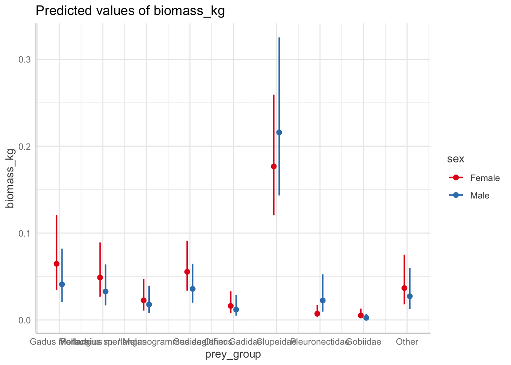

```r
plot(ggeffects::ggpredict(h6, c("prey_group", "sex")))
```

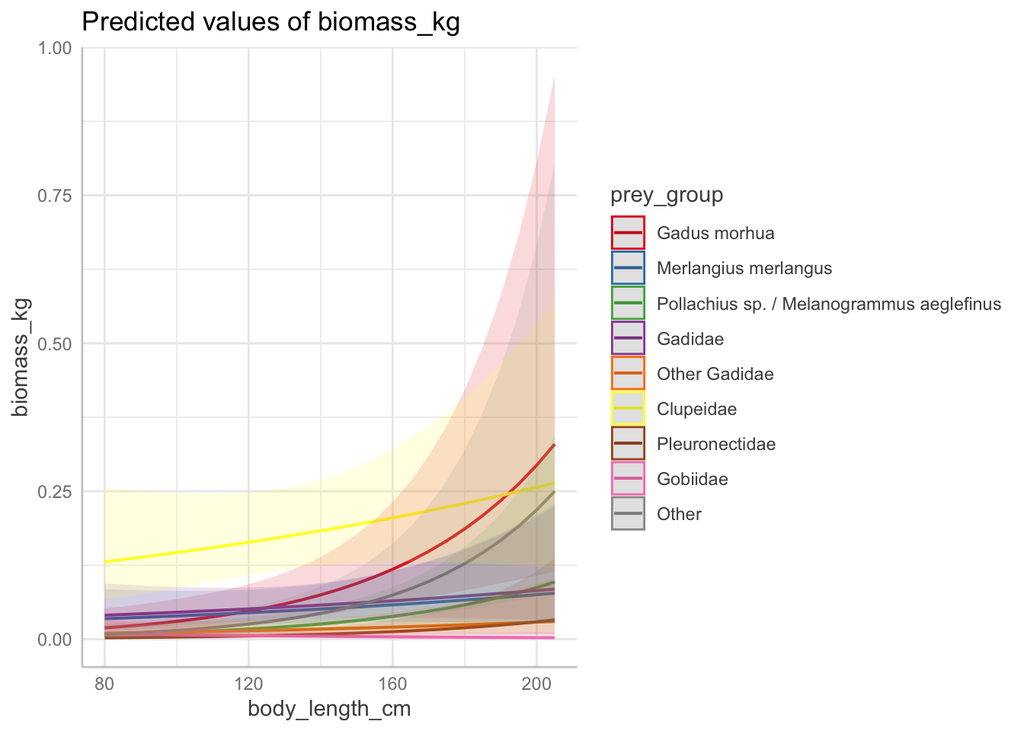

```r
plot(ggeffects::ggpredict(h6, c("body_length_cm", "prey_group")))
```

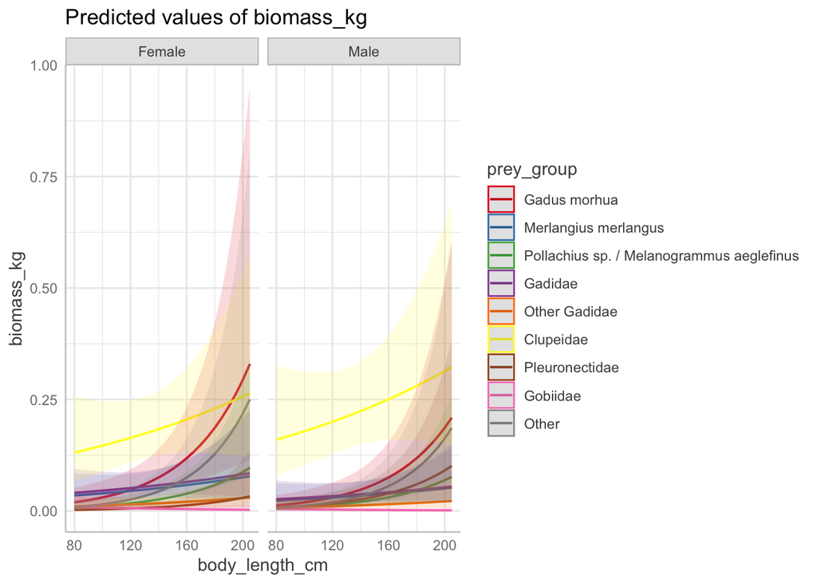

```r
plot(ggeffects::ggpredict(h6, c("body_length_cm", "prey_group", "sex")))
```

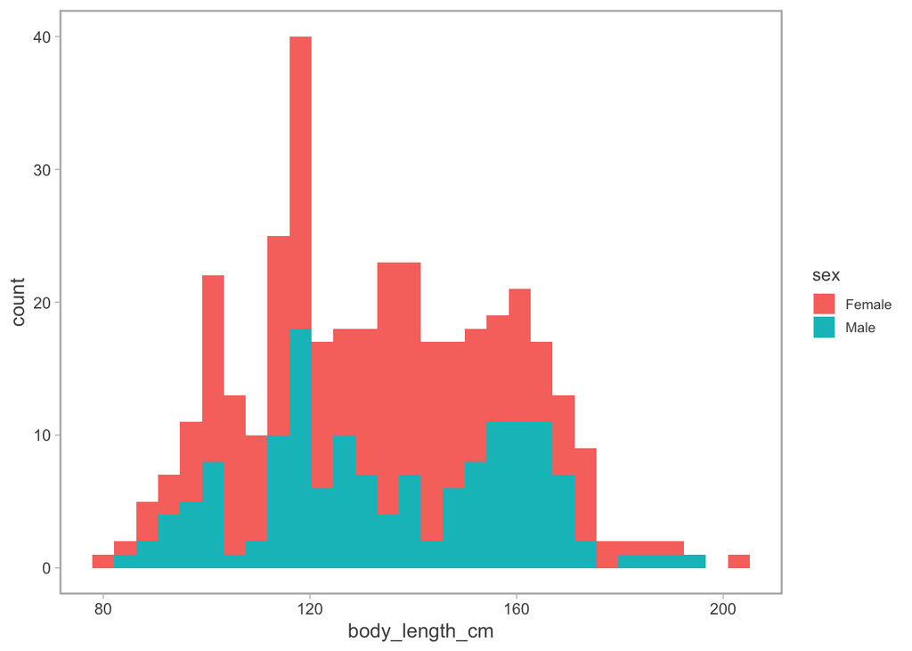

```r
diet_model_hybrid |>
  distinct(sample_id, body_length_cm, sex) |>
  ggplot(aes(body_length_cm, fill = sex)) +
  geom_histogram()
```

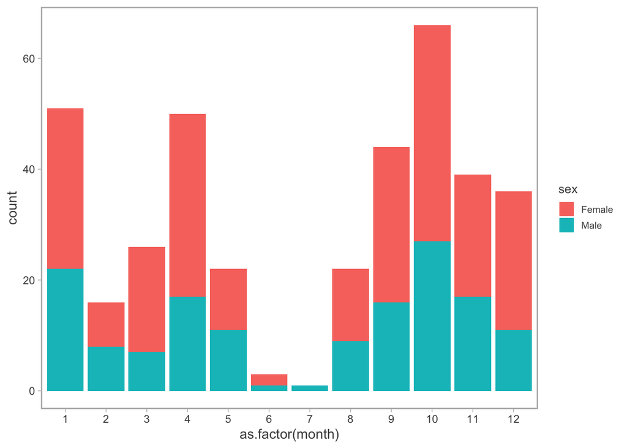

```r
diet_model_hybrid |>
  distinct(sample_id, month, sex) |>
  ggplot(aes(as.factor(month), fill = sex)) +
  geom_bar()
```

## Hybrid biomass predictions per sample

These plots keep predictions on the biomass-per-sample scale instead of converting them to relative composition. This is useful when the question is about absolute prey biomass rather than diet proportion.

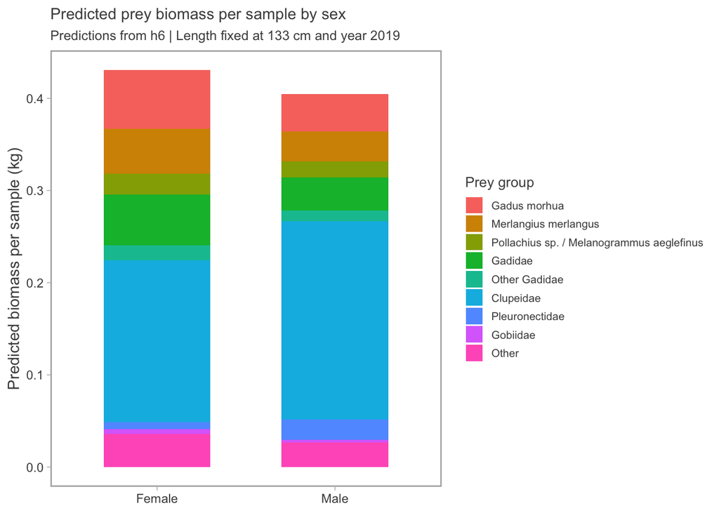

```r
# Sex effect on biomass/sample from the simpler spatial hybrid model.
nd_bio_sex <- expand_grid(
  sex = factor(c("Female", "Male"), levels = levels(diet_model_hybrid$sex)),
  prey_group = factor(prey_group_levels, levels = prey_group_levels)
) |>
  mutate(
    body_length_cm = pred_length_hybrid,
    year = pred_year_hybrid,
    year_ct = year - year_center,
    year_f = factor(year, levels = levels(diet_model_hybrid$year_f)),
    quarter_f = factor(1, levels = levels(diet_model_hybrid$quarter_f)),
    X = median(diet_model_hybrid$X, na.rm = TRUE),
    Y = median(diet_model_hybrid$Y, na.rm = TRUE)
  )

p_bio_sex <- predict(h6, newdata = nd_bio_sex, re_form = NA, re_form_iid = NA)

bio_sex <- nd_bio_sex |>
  bind_cols(as_tibble(p_bio_sex) |> select(est)) |>
  mutate(biomass = exp(est))

plot_bio_sex_stack <- bio_sex |>
  ggplot(aes(sex, biomass, fill = prey_group)) +
  geom_col(width = 0.6) +
  labs(
    title = "Predicted prey biomass per sample by sex",
    subtitle = paste("Predictions from h6 | Length fixed at", round(pred_length_hybrid, 1), "cm and year", pred_year_hybrid),
    x = NULL,
    y = "Predicted biomass per sample (kg)",
    fill = "Prey group"
  )

plot_bio_gadus_sex <- bio_sex |>
  filter(prey_group == "Gadus morhua") |>
  ggplot(aes(sex, biomass, fill = sex)) +
  geom_col(width = 0.6, show.legend = FALSE) +
  labs(
    title = "Predicted Gadus morhua biomass per sample by sex",
    subtitle = paste("Predictions from h6 | Length fixed at", round(pred_length_hybrid, 1), "cm and year", pred_year_hybrid),
    x = NULL,
    y = "Predicted biomass per sample (kg)"
  )

# Length effect on biomass/sample.
length_seq_hybrid <- seq(
  quantile(diet_model_hybrid$body_length_cm, 0.1, na.rm = TRUE),
  quantile(diet_model_hybrid$body_length_cm, 0.9, na.rm = TRUE),
  length.out = 60
)

nd_bio_length <- expand_grid(
  body_length_cm = length_seq_hybrid,
  sex = factor(c("Female", "Male"), levels = levels(diet_model_hybrid$sex)),
  prey_group = factor(prey_group_levels, levels = prey_group_levels)
) |>
  mutate(
    year = pred_year_hybrid,
    year_ct = year - year_center,
    year_f = factor(year, levels = levels(diet_model_hybrid$year_f)),
    quarter_f = factor(1, levels = levels(diet_model_hybrid$quarter_f)),
    X = median(diet_model_hybrid$X, na.rm = TRUE),
    Y = median(diet_model_hybrid$Y, na.rm = TRUE)
  )

p_bio_length <- predict(h6, newdata = nd_bio_length, re_form = NA, re_form_iid = NA)

bio_length <- nd_bio_length |>
  bind_cols(as_tibble(p_bio_length) |> select(est)) |>
  mutate(biomass = exp(est))

plot_bio_length_gadus <- bio_length |>
  filter(prey_group == "Gadus morhua") |>
  ggplot(aes(body_length_cm, biomass, color = sex)) +
  geom_line(linewidth = 1) +
  labs(
    title = "Predicted Gadus morhua biomass per sample over seal length",
    subtitle = paste("Predictions from h6 | Year fixed at", pred_year_hybrid),
    x = "Body length (cm)",
    y = "Predicted biomass per sample (kg)",
    color = "Sex"
  )

# Quarter effect on biomass/sample.
nd_bio_quarter <- expand_grid(
  quarter_f = factor(c(1:4), levels = levels(diet_model_hybrid$quarter_f)),
  sex = factor(c("Female", "Male"), levels = levels(diet_model_hybrid$sex)),
  prey_group = factor(prey_group_levels, levels = prey_group_levels)
) |>
  mutate(
    body_length_cm = pred_length_hybrid,
    year = pred_year_hybrid,
    year_ct = year - year_center,
    year_f = factor(year, levels = levels(diet_model_hybrid$year_f)),
    X = median(diet_model_hybrid$X, na.rm = TRUE),
    Y = median(diet_model_hybrid$Y, na.rm = TRUE)
  )

p_bio_quarter <- predict(h10, newdata = nd_bio_quarter, re_form = NA, re_form_iid = NA)

bio_quarter <- nd_bio_quarter |>
  bind_cols(as_tibble(p_bio_quarter) |> select(est)) |>
  mutate(biomass = exp(est))

plot_bio_quarter_gadus <- bio_quarter |>
  filter(prey_group == "Gadus morhua") |>
  ggplot(aes(as.numeric(as.character(quarter_f)), biomass, color = sex)) +
  geom_line(linewidth = 1) +
  geom_point(size = 2) +
  scale_x_continuous(breaks = 1:4) +
  labs(
    title = "Predicted Gadus morhua biomass per sample by quarter",
    subtitle = paste("Predictions from h10 | Length fixed at", round(pred_length_hybrid, 1), "cm and year", pred_year_hybrid),
    x = "Quarter",
    y = "Predicted biomass per sample (kg)",
    color = "Sex"
  )

plot_bio_quarter_stack <- bio_quarter |>
  ggplot(aes(quarter_f, biomass, fill = prey_group)) +
  geom_col() +
  facet_wrap(~sex) +
  labs(
    title = "Predicted prey biomass per sample by quarter",
    subtitle = paste("Predictions from h10 | Length fixed at", round(pred_length_hybrid, 1), "cm and year", pred_year_hybrid),
    x = "Quarter",
    y = "Predicted biomass per sample (kg)",
    fill = "Prey group"
  )

# Cod vs whiting over time at a representative location.
nd_cod_whiting_time <- expand_grid(
  year = sort(unique(diet_model_hybrid$year)),
  sex = factor(c("Female", "Male"), levels = levels(diet_model_hybrid$sex)),
  prey_group = factor(c("Gadus morhua", "Merlangius merlangus"), levels = prey_group_levels)
) |>
  mutate(
    body_length_cm = pred_length_hybrid,
    year_ct = year - year_center,
    year_f = factor(year, levels = levels(diet_model_hybrid$year_f)),
    quarter_f = factor(1, levels = levels(diet_model_hybrid$quarter_f)),
    X = median(diet_model_hybrid$X, na.rm = TRUE),
    Y = median(diet_model_hybrid$Y, na.rm = TRUE)
  )

p_cod_whiting_time <- predict(h6, newdata = nd_cod_whiting_time, re_form = NA, re_form_iid = NA)

cod_whiting_time <- nd_cod_whiting_time |>
  bind_cols(as_tibble(p_cod_whiting_time) |> select(est)) |>
  mutate(biomass = exp(est))

plot_cod_whiting_time <- cod_whiting_time |>
  ggplot(aes(year, biomass, color = prey_group)) +
  geom_line(linewidth = 1) +
  geom_point(size = 1.5) +
  facet_wrap(~sex) +
  labs(
    title = "Predicted cod and whiting biomass per sample over time",
    subtitle = paste("Predictions from h6 | Length fixed at", round(pred_length_hybrid, 1), "cm at a representative location"),
    x = "Year",
    y = "Predicted biomass per sample (kg)",
    color = "Prey group"
  )

# Year-space biomass maps from the spatiotemporal model.
map_years_hybrid <- unique(c(min(diet_model_hybrid$year), median(sort(unique(diet_model_hybrid$year))) |> round(), max(diet_model_hybrid$year)))

pg_bio_space <- pred_grid_base |>
  filter(year %in% map_years_hybrid) |>
  expand_grid(
    sex = factor(c("Female", "Male"), levels = levels(diet_model_hybrid$sex)),
    prey_group = factor(prey_group_levels, levels = prey_group_levels)
  ) |>
  mutate(
    body_length_cm = pred_length_hybrid,
    quarter_f = factor(1, levels = levels(diet_model_hybrid$quarter_f)),
    year_f = factor(year, levels = levels(diet_model_hybrid$year_f)),
    year_ct = year - year_center
  )

p_bio_space <- predict(h8, newdata = pg_bio_space)

bio_space <- pg_bio_space |>
  bind_cols(as_tibble(p_bio_space) |> select(est)) |>
  mutate(biomass = exp(est)) |>
  filter(prey_group == "Gadus morhua")

plot_bio_space_gadus <- bio_space |>
  ggplot(aes(X * 1000, Y * 1000, fill = biomass)) +
  geom_raster() +
  geom_sf(data = land, fill = "grey90", linewidth = 0.2, inherit.aes = FALSE) +
  viridis::scale_fill_viridis() +
  coord_sf(
    crs = 32632,
    xlim = range(bio_space$X * 1000),
    ylim = range(bio_space$Y * 1000),
    expand = FALSE
  ) +
  labs(
    title = "Predicted Gadus morhua biomass per sample in space",
    subtitle = paste("Predictions from h8 | Length fixed at", round(pred_length_hybrid, 1), "cm"),
    x = "Longitude",
    y = "Latitude",
    fill = "Biomass\n(kg/sample)"
  ) +
  theme(axis.text.x = element_text(angle = 90)) +
  facet_grid(sex ~ year)

plot_bio_sex_stack
```

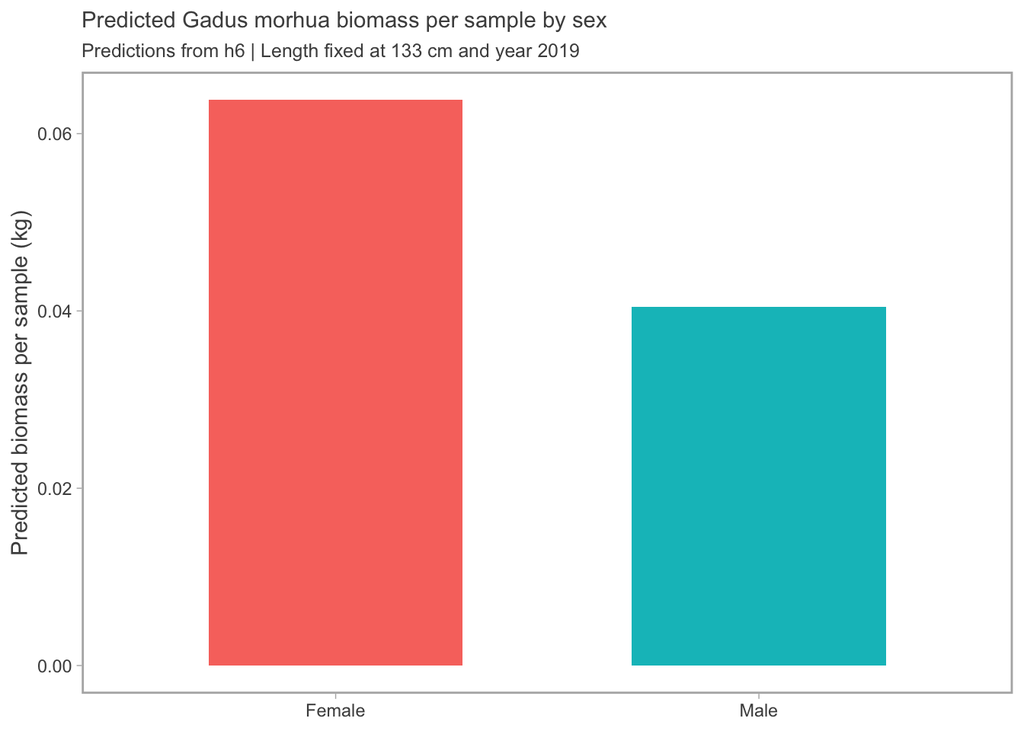

```r
plot_bio_gadus_sex
```

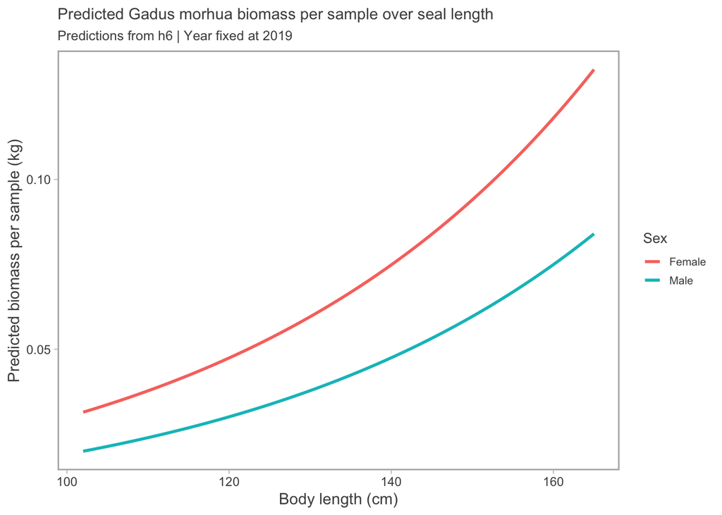

```r
plot_bio_length_gadus
```

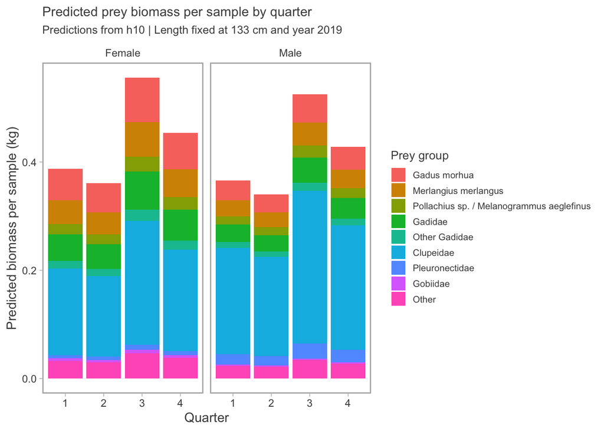

```r
plot_bio_quarter_stack
```